# Honey Production visualization analysis:-

# 1. Import required libraries and read the dataset.

```python
# Importing the required Libraries:-
import pandas as pd
import numpy as np
import matplotlib.pyplot as plt
import seaborn as sns
import plotly.express as ps
import warnings
warnings.filterwarnings("ignore")
```

```python
# Assigning the csv file to honey_production:-
honey_production = pd.read_csv("honeyproduction.csv")
df = honey_production.copy()
```

# 2. Check the first few samples, shape, info of the data and try to familiarize yourself with different features.

```python
# Checking the shape of the columns:-
df.shape
# This consist of around 626 columns and 8 columns..
```

```
(626, 8)
```

```python
df.info()

# After ckecking the info the yieldpercol & year is int, the state is object rest of the others were float..
```

```
<class 'pandas.core.frame.DataFrame'>
RangeIndex: 626 entries, 0 to 625
Data columns (total 8 columns):
 #   Column       Non-Null Count  Dtype
---  ------       --------------  -----
 0   state        626 non-null    object
 1   numcol       626 non-null    float64
 2   yieldpercol  626 non-null    int64
 3   totalprod    626 non-null    float64
 4   stocks       626 non-null    float64
 5   priceperlb   626 non-null    float64
 6   prodvalue    626 non-null    float64
 7   year         626 non-null    int64
dtypes: float64(5), int64(2), object(1)
memory usage: 39.2+ KB
```

```python
df.columns
```

```
Index(['state', 'numcol', 'yieldpercol', 'totalprod', 'stocks', 'priceperlb',
       'prodvalue', 'year'],
      dtype='object')
```

```python
df.sample()
```

|  | state | numcol | yieldpercol | totalprod | stocks | priceperlb | prodvalue | year |
| --- | --- | --- | --- | --- | --- | --- | --- | --- |
| 31 | OR | 50000.0 | 45 | 2250000.0 | 1620000.0 | 0.9 | 2025000.0 | 1998 |

```python
df
```

|  | state | numcol | yieldpercol | totalprod | stocks | priceperlb | prodvalue | year |
| --- | --- | --- | --- | --- | --- | --- | --- | --- |
| 0 | AL | 16000.0 | 71 | 1136000.0 | 159000.0 | 0.72 | 818000.0 | 1998 |
| 1 | AZ | 55000.0 | 60 | 3300000.0 | 1485000.0 | 0.64 | 2112000.0 | 1998 |
| 2 | AR | 53000.0 | 65 | 3445000.0 | 1688000.0 | 0.59 | 2033000.0 | 1998 |
| 3 | CA | 450000.0 | 83 | 37350000.0 | 12326000.0 | 0.62 | 23157000.0 | 1998 |
| 4 | CO | 27000.0 | 72 | 1944000.0 | 1594000.0 | 0.70 | 1361000.0 | 1998 |
| ... | ... | ... | ... | ... | ... | ... | ... | ... |
| 621 | VA | 4000.0 | 41 | 164000.0 | 23000.0 | 3.77 | 618000.0 | 2012 |
| 622 | WA | 62000.0 | 41 | 2542000.0 | 1017000.0 | 2.38 | 6050000.0 | 2012 |
| 623 | WV | 6000.0 | 48 | 288000.0 | 95000.0 | 2.91 | 838000.0 | 2012 |
| 624 | WI | 60000.0 | 69 | 4140000.0 | 1863000.0 | 2.05 | 8487000.0 | 2012 |
| 625 | WY | 50000.0 | 51 | 2550000.0 | 459000.0 | 1.87 | 4769000.0 | 2012 |

626 rows × 8 columns

```python
# Using describe function for statistical summary...
df.describe()
```

|  | numcol | yieldpercol | totalprod | stocks | priceperlb | prodvalue | year |
| --- | --- | --- | --- | --- | --- | --- | --- |
| count | 626.000000 | 626.000000 | 6.260000e+02 | 6.260000e+02 | 626.000000 | 6.260000e+02 | 626.000000 |
| mean | 60284.345048 | 62.009585 | 4.169086e+06 | 1.318859e+06 | 1.409569 | 4.715741e+06 | 2004.864217 |
| std | 91077.087231 | 19.458754 | 6.883847e+06 | 2.272964e+06 | 0.638599 | 7.976110e+06 | 4.317306 |
| min | 2000.000000 | 19.000000 | 8.400000e+04 | 8.000000e+03 | 0.490000 | 1.620000e+05 | 1998.000000 |
| 25% | 9000.000000 | 48.000000 | 4.750000e+05 | 1.430000e+05 | 0.932500 | 7.592500e+05 | 2001.000000 |
| 50% | 26000.000000 | 60.000000 | 1.533000e+06 | 4.395000e+05 | 1.360000 | 1.841500e+06 | 2005.000000 |
| 75% | 63750.000000 | 74.000000 | 4.175250e+06 | 1.489500e+06 | 1.680000 | 4.703250e+06 | 2009.000000 |
| max | 510000.000000 | 136.000000 | 4.641000e+07 | 1.380000e+07 | 4.150000 | 6.961500e+07 | 2012.000000 |

```python
df.describe(include="O")
```

|  | state |
| --- | --- |
| count | 626 |
| unique | 44 |
| top | AL |
| freq | 15 |

# 3. Display the percentage distribution of the data in each year using the pie chart.

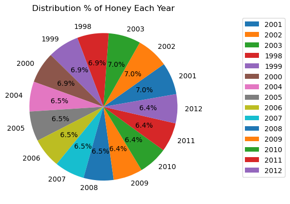

```python
# using the matplot to plot the pie plot by the function plt.pie
plt.pie(df.year.value_counts(),autopct="%.1f%%",radius=1.0,labels = ["2001","2002","2003","1998","1999","2000","2004","2005","2006","2007","2008","2009","2010","2011","2012"],startangle=10)
#Determining the tite
plt.title("Distribution % of Honey Each Year")
#To show case the legend determining the location and also providing bbox_to_anchor to place the legend in the proper area..
plt.legend(df["year"],loc="upper right",bbox_to_anchor=(1.5,1),labels=["2001","2002","2003","1998","1999","2000","2004","2005","2006","2007","2008","2009","2010","2011","2012"])
plt.show()
```

# 4. Plot and Understand the distribution of the variable "price per lb" using displot, and write your findings.

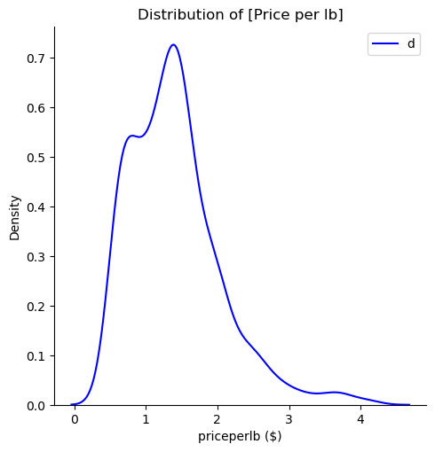

```python
# Showing up the displot without Histogram
sns.displot(df["priceperlb"],kind="kde",color="b")
plt.title("Distribution of [Price per lb]")
plt.xlabel("priceperlb ($)")
plt.legend("displot",loc="upper right")
plt.show()
```

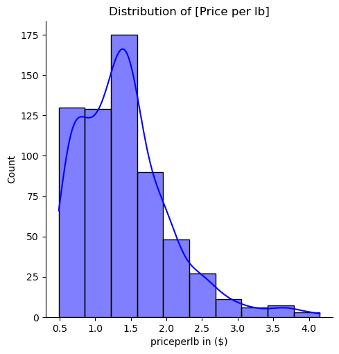

```python
# With Histogram:-
sns.displot(df["priceperlb"],kind="hist",color="blue",kde=True,bins=10)
plt.title("Distribution of [Price per lb]")
plt.xlabel("priceperlb in ($)")
plt.show()
```

#### since the priceperlb is the prodvalue/totalprod which will give the value.

#### when the production increases the product value also increases.

# 5. Plot and understand the relationship between the variables 'numcol' and 'prodval' through scatterplot, and write your findings.

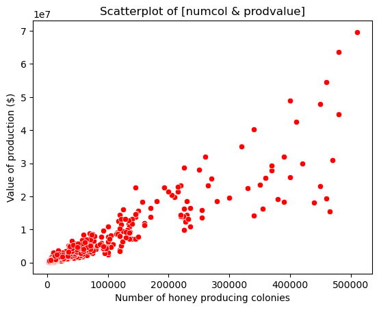

```python
# using seaborn for plotting..
# Plotted for numcoln and prodvalue with respect to year..
sns.scatterplot(data=df, x="numcol",y="prodvalue",color="red")
plt.title("Scatterplot of [numcol & prodvalue]")
plt.xlabel("Number of honey producing colonies")
plt.ylabel("Value of production ($)")
plt.show()
```

#### The highest numcol is 500000 which holds the value of 7*e7.

#### And also there is no patterned error..

# 6. Plot and understand the relationship between categorical variable 'year' and a numerical variable'prodvalue' through boxplot, and write your findings.

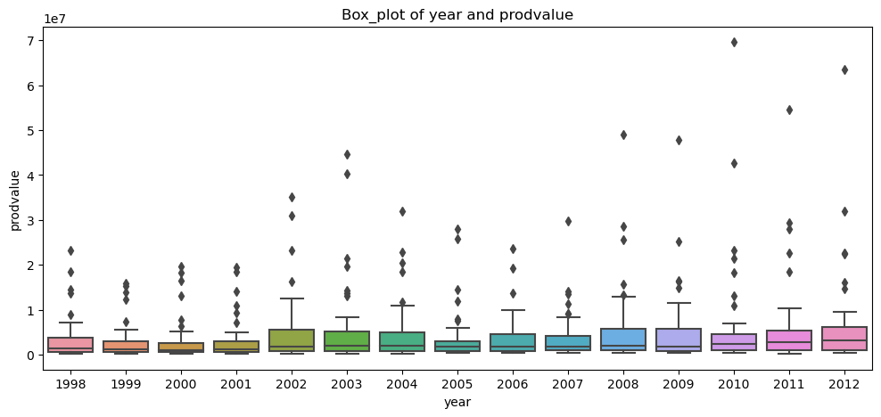

```python
#using seaborn library to plot the box plot to understand the relation ship between twi variables...
# Determining the figure size to avoid overlapping of the variables..
plt.figure(figsize=(12,5))
sns.boxplot(data=df,x="year",y="prodvalue")
plt.title("Box_plot of year and prodvalue")
plt.show()
```

#### Since for the year and prodvalue for this holds so many outliers in it.

#### The largest outlier which was in the year 2010

#### All the mean,median & mode value holds in the value of range between 0 and 1..

# 7. Visualize and understand the relationship between the multiple pairs of variables throughout different years using pairplot and add your inferences. (use columns 'numcol', 'yield percol', 'total prod', 'prodvalue','year')

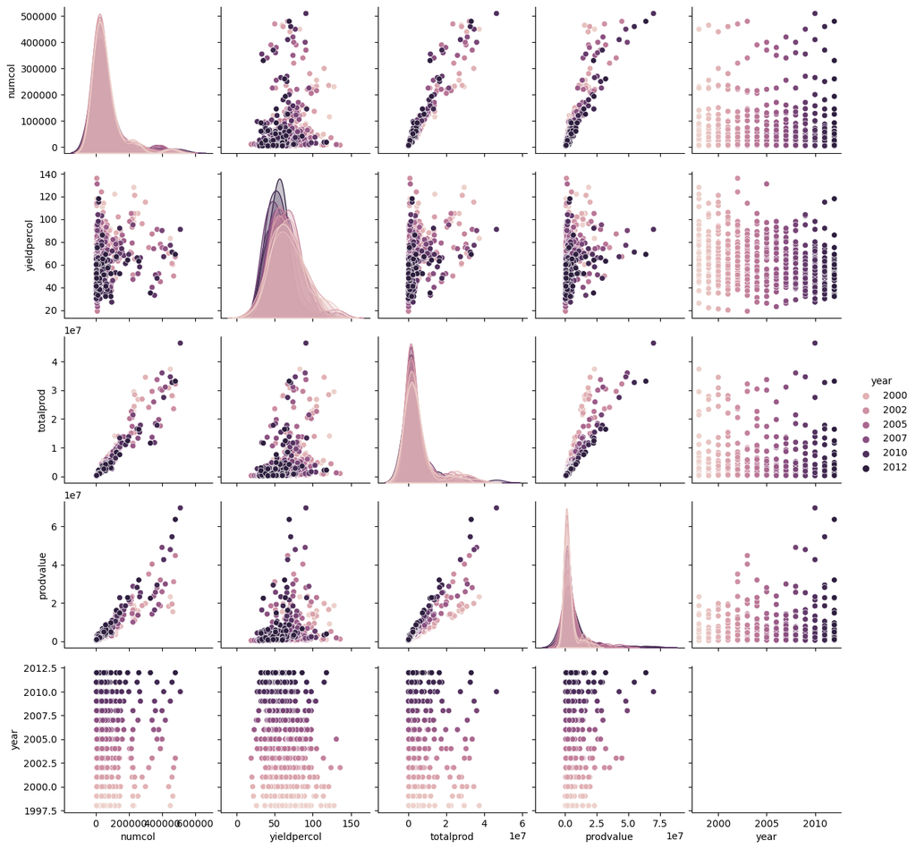

```python
sns.pairplot(data=df,vars=["numcol", "yieldpercol", "totalprod", "prodvalue","year"],hue="year")
plt.show()
```

#### year vs yieldpercol the more number of values lies in between 50 - 100 only throughout the year the distribution tend to lies in the same range.

#### year vs totalprod the values lies between 0-2

#### In the same case the prodvalue lies between 0-2.5

#### This pair plot shows that distribution all the data points of years were of this were positively skewed.

# 8. Display the correlation values using a plot and add your inferences. (use columns 'numcol', 'yield percol','total prod', 'stocks', 'price per lb', 'prodvalue')

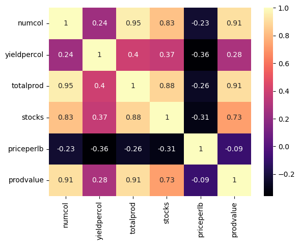

```python
sns.heatmap(df[["numcol", "yieldpercol","totalprod","stocks","priceperlb","prodvalue"]].corr(),annot=True,cmap="magma")
plt.show()
```

### The Top negatively co-related pair

#### 1) yieldpercol and priceperlb (-0.36)

#### 2) priceperlb and stocks (-0.31)

#### 3) priceperlb and totalprod (-0.26)

#### The Top Positively co-related pair

#### 1) totalprod and numcol (0.95)

#### 2) prodvalue and numcol (0.91) | totalprod and prodvalue (0.91)

#### 3) totalprod and stocks (0.88)

#### 4) stocks and numcol(0.83)

#### 5) stocks and prodvalue(0.73)

### From these valuable insights we can make regression models which will be best to make good predictions...